# Estudio sobre los Top 200 Weekly (Global) de Spotify (2017 - 2021)

# Regresiones

## Regresión 1

La gráfica **“Canciones con ranking 100 en la data”** muestra el comportamiento entre la variable **Streams (millones)** y la variable **Tiempo (semanas)**.

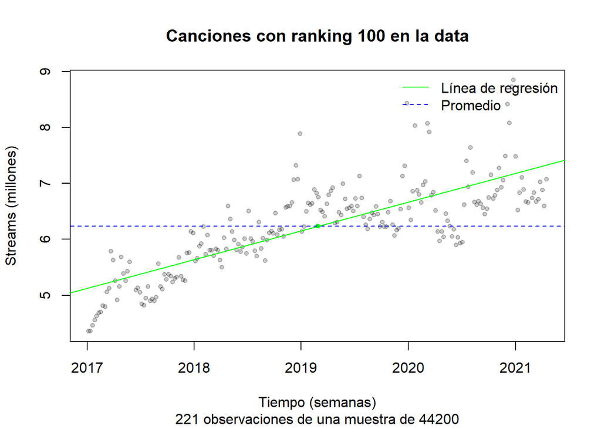

```r
plot(R$Week [R$Rank == 100],
     (R$Streams [R$Rank == 100] / 1000000),
     pch = 20,
     col = rgb(0, 0, 0, 0.2),
     main = "Canciones con ranking 100 en la data", xlab = "Tiempo (semanas)",
     ylab = "Streams (millones)",
     sub = paste(sum (!is.na (R$Week [R$Rank== 100])), "observaciones de una muestra de", nrow (R))
)
points(mean(R$Week [R$Rank == 100], na.rm = TRUE),
       mean((R$Streams [R$Rank == 100] / 1000000), na.rm = TRUE),
       pch = 20,
       col = "green"
)
abline(h = mean((R$Streams [R$Rank == 100] / 1000000), na.rm = TRUE),
       lty = 2,
       col = "blue"
)
abline(lm( (R$Streams [R$Rank == 100] / 1000000) ~ R$Week [R$Rank == 100]),
       col = "green"
)
legend("topright",
       legend = c ("Línea de regresión", "Promedio"),
       col = c ("green", "blue"),
       lty = c (1, 2),
       bty = "n"
)
```

```r
modelo1 <- lm( (R$Streams [R$Rank == 100] / 1000000) ~ R$Week [R$Rank == 100])
```

Se puede observar una relación o tendencia directa (directamente proporcional) que se modela mediante una recta con pendiente positiva. Vemos que conforme pasan los años, aquellas canciones con **ranking 100** tienden a aumentar su Nº de streams. Se podría plantear la siguiente hipótesis, que conforme pasa el tiempo, la competencia por el ranking 100 se vuelve más **difícil**, dado que, una canción debe tener un mayor Nº de streams para ocupar dichos rankings. Para la validación de esta hipótesis se analizará el **resumen de la regresión**.

**Análisis de residuos**

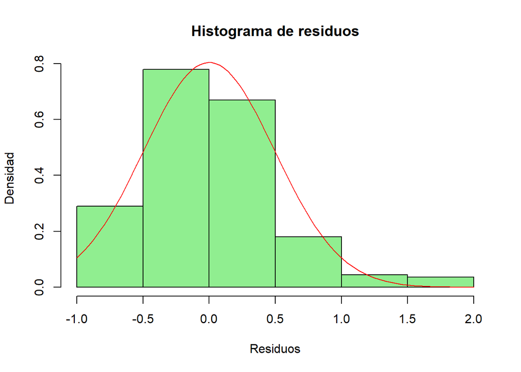

```r
hist (modelo1$residuals,
      prob = TRUE,
      main = "Histograma de residuos",
      xlab = "Residuos",
      ylab = "Densidad",
      col = "lightgreen",
      )
curve(dnorm(x,
            mean=mean(modelo1$residuals),
            sd=sd(modelo1$residuals)),
      add=TRUE, col="red"
      )
```

```r
cat("Promedio de los residuos:", mean (modelo1$residuals),"\n\n")
```

```
## Promedio de los residuos: -5.007211e-17
```

Se observa que los **residuos** tienen una distribución **cercana a la normal**. Además, su mediana es aproximadamente 0, esto asegura la linealidad del modelo. Con ello concluimos que la lineal de ajuste hallada cumple con las características de una buena regresión.

**Gráficas de diagnóstico**

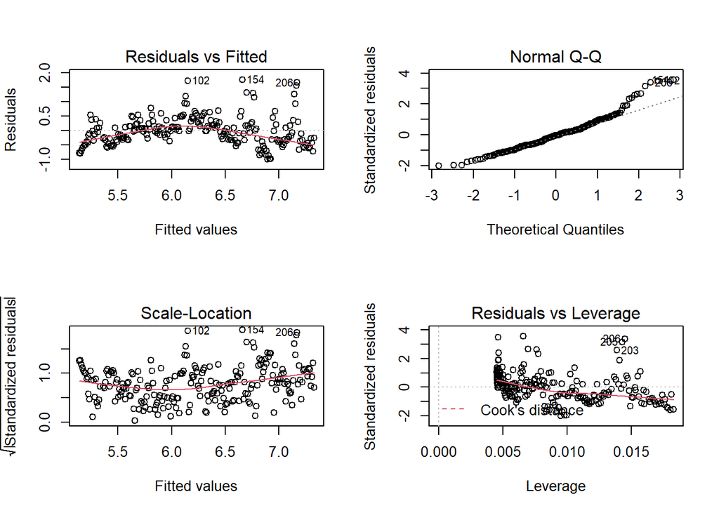

```r
op=par(mfrow=c(2,2))
plot (modelo1)
```

De acuerdo con las gráficas de diagnóstico de la línea de ajuste, se tienen las siguientes observaciones:

**Con respecto a la gráfica de Residuos vs. Valores ajustados:** - Se pueden observar residuos positivos y negativos distribuidos alrededor de la línea roja. - Los residuos no son homocedásticos ya que no se aprecia una distribución uniforme.

**Con respecto a la gráfica de la Normal Q-Q:** - Se puede visualizar en la gráfica que algunos puntos que se encuentran en la parte superior no siguen la línea de la normal.

**Con respecto a la gráfica Scale Location:** - En la gráfica se aprecia que no hay uniformidad a lo largo de la línea, por lo tanto los residuos son heterocedásticos.

**Con respecto a la gráfica Residual vs. Leverage:** - Podemos notar que no hay puntos que estén cerca de las líneas de la distancia de Cook. Entonces se puede decir que no hay puntos influyentes en el modelo de regresión

**Resumen de la regresión**

```r
summary(modelo1)
```

```
##
## Call:
## lm(formula = (R$Streams[R$Rank == 100]/1e+06) ~ R$Week[R$Rank ==
##     100])
##
## Residuals:
##      Min       1Q   Median       3Q      Max
## -0.99899 -0.33267 -0.02216  0.24226  1.76731
##
## Coefficients:
##                         Estimate Std. Error t value Pr(>|t|)
## (Intercept)           -1.896e+01  1.338e+00  -14.18   <2e-16 ***
## R$Week[R$Rank == 100]  1.404e-03  7.449e-05   18.84   <2e-16 ***
## ---
## Signif. codes:  0 '***' 0.001 '**' 0.01 '*' 0.05 '.' 0.1 ' ' 1
##
## Residual standard error: 0.4973 on 219 degrees of freedom
## Multiple R-squared:  0.6185, Adjusted R-squared:  0.6167
## F-statistic:   355 on 1 and 219 DF,  p-value: < 2.2e-16
```

**Función de regresión1**

```r
regression1_function = function(x)
{
  y = 0.001404*x -18.96
  return(x)
}
```

## Regresión 2

La gráfica **“Canciones con ranking 200 en la data”** muestra el comportamiento entre la variable **Streams (millones)** y la variable **Tiempo (semanas)**.

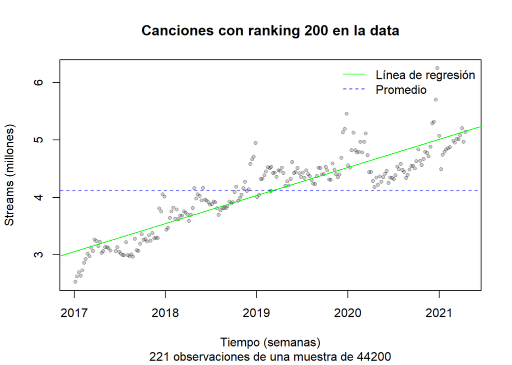

```r
plot(R$Week [R$Rank == 200],
     (R$Streams [R$Rank == 200] / 1000000),
     pch = 20,
     col = rgb(0, 0, 0, 0.2),
     main = "Canciones con ranking 200 en la data",
     xlab = "Tiempo (semanas)",
     ylab = "Streams (millones)",
     sub = paste(sum (!is.na (R$Week [R$Rank == 200])), "observaciones de una muestra de", nrow (R))
)
points(mean(R$Week [R$Rank == 200], na.rm = TRUE),
       mean((R$Streams [R$Rank == 200] / 1000000), na.rm = TRUE),
       pch = 20,
       col = "green"
)
abline(h = mean((R$Streams [R$Rank == 200] / 1000000), na.rm = TRUE),
       lty = 2,
       col = "blue"
)
abline(lm( (R$Streams [R$Rank == 200] / 1000000) ~ R$Week [R$Rank == 200]),
       col = "green"
)
legend("topright",
       legend = c ("Línea de regresión", "Promedio"),
       col = c ("green", "blue"),
       lty = c (1, 2),
       bty = "n"
)
```

```r
modelo2 <- lm( (R$Streams [R$Rank == 200] / 1000000) ~ R$Week [R$Rank == 200])
```

**Análisis de residuos**

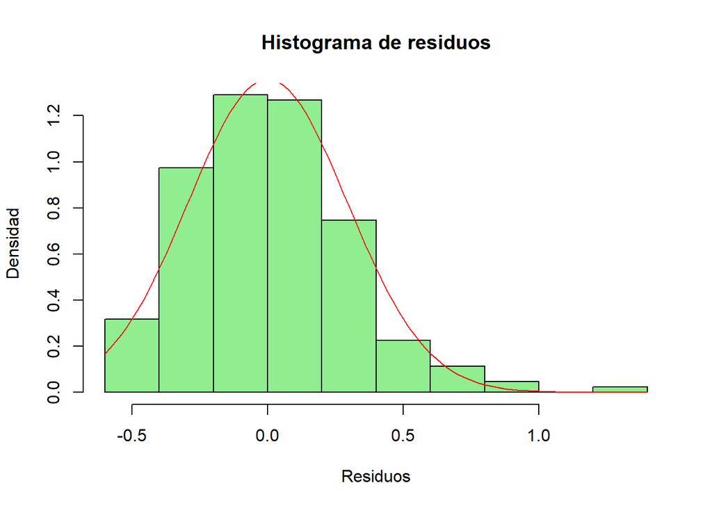

```r
hist (modelo2$residuals,
      prob = TRUE,
      main = "Histograma de residuos",
      xlab = "Residuos",
      ylab = "Densidad",
      col = "lightgreen",
      )
curve(dnorm(x,
            mean=mean(modelo2$residuals),
            sd=sd(modelo2$residuals)),
      add=TRUE, col="red"
      )
```

```r
cat("Promedio de los residuos:", mean (modelo2$residuals),"\n\n")
```

```
## Promedio de los residuos: 2.248486e-17
```

Se observa que los **residuos** tienen una distribución **cercana a la normal**. Además, su mediana es aproximadamente 0, esto asegura la linealidad del modelo. Con ello concluimos que la lineal de ajuste hallada cumple con las características de una buena regresión.

**Gráficas de diagnóstico**

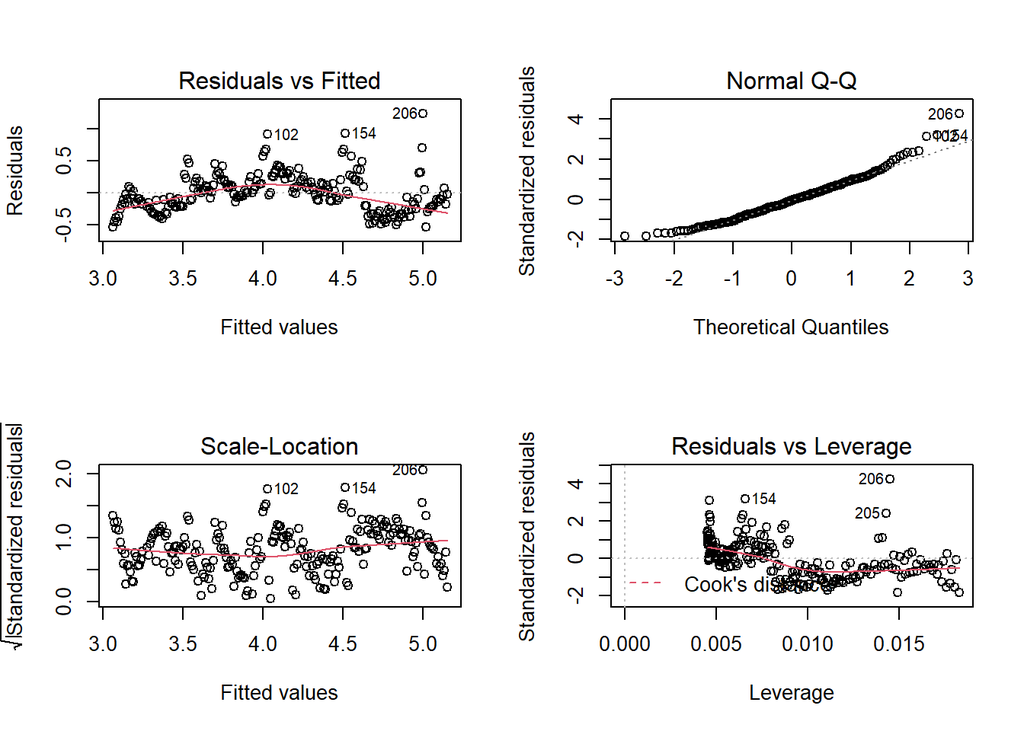

```r
op=par(mfrow=c(2,2))
plot (modelo2)
```

De acuerdo con las gráficas de diagnóstico de la línea de ajuste, se tienen las siguientes observaciones:

**Con respecto a la gráfica de Residuos vs. Valores ajustados:**

- En la gráfica de residuos y valores ajustados se observa claramente que los residuos no son uniformes, por lo tanto no se presenta homocedasticidad.

**Con respecto a la gráfica de la Normal Q-Q:**

- En la gráfica se puede visualizar que existen algunos puntos en la parte superior que no están en la línea de la normal.

**Con respecto a la gráfica Scale Location:**

- Los valores no están distribuidos uniformemente a lo largo de la línea. Se dice en este caso que no es homocedástico

**Con respecto a la gráfica Residual vs. Leverage:**

- En la gráfica no se aprecia ningún punto que se acerca a la distancia de Cook. Entonces no hay puntos influyentes en el modelo de regresión.

**Resumen de la regresión**

```r
summary (modelo2)
```

```
##
## Call:
## lm(formula = (R$Streams[R$Rank == 200]/1e+06) ~ R$Week[R$Rank ==
##     200])
##
## Residuals:
##      Min       1Q   Median       3Q      Max
## -0.53534 -0.20941 -0.01718  0.17833  1.24374
##
## Coefficients:
##                         Estimate Std. Error t value Pr(>|t|)
## (Intercept)           -1.999e+01  7.918e-01  -25.25   <2e-16 ***
## R$Week[R$Rank == 200]  1.342e-03  4.409e-05   30.45   <2e-16 ***
## ---
## Signif. codes:  0 '***' 0.001 '**' 0.01 '*' 0.05 '.' 0.1 ' ' 1
##
## Residual standard error: 0.2943 on 219 degrees of freedom
## Multiple R-squared:  0.8089, Adjusted R-squared:  0.808
## F-statistic:   927 on 1 and 219 DF,  p-value: < 2.2e-16
```

```r
regression2_function = function(x)
{
  y = 0.001342*x -19.99
  return(y)
}
```

# Variables Dependientes

Para este caso, hemos elegido las siguientes variables:

**Seguidores y Reproducciones:** Siendo **seguidores** la variable independiente y **reproducciones** la variable dependiente .

**Semana del año y Reproducciones:** Siendo **semana del año** la variable independiente y **reproducciones** la variable dependiente.

**Duración y Reproducciones:** Siendo **duración** la variable independiente y **reproducciones** la variable dependiente.

**Duración y Followers:** Siendo **duración** la variable independiente y **followers** la variable independiente.

# Tendencias

Luego de haber calculado los modelos respectivos para sus respectivas variables dependientes e independientes, procedemos a probar nuestro modelo con nuevos datos de entrada.

**La pregunta en cuestión: ¿Se puede predecir la cantidad de streams que se tendrá en un año respectivo?**

```r
ano_calculado = function(x)
{
  ano = 107 + 52*(x-2021)
  return(ano)
}
ano = ano_calculado(2025)
regression1_function(ano)
```

```
## [1] 315
```

```r
regression2_function(ano)
```

```
## [1] -19.56727
```

# Reflexiones y conclusiones

A partir del análisis descriptivo, inferencial y predictivo realizado en el presente estudio, se ha podido obtener las siguientes conclusiones:

** Los diagramas estadísticos permitieron un correcto análisis y buenas observaciones acerca de las variables**

En primer lugar, se pudo ver que la suposición **“A mayor duración de la canción, mayor será la cantidad de reproducciones (Streams)”** no necesariamente es correcta.

En segundo lugar, la canción más escuchada (con más streams) fue: **drivers license**, la cual fue compuesta por **Olivia Rodrigo** con el género **[‘pop’, ‘post-teen pop’]**.

En tercer lugar, pudimos ver en el análisis del artista Ed Sheeran que ha tenido picos de streams cada cierto tiempo. Esto podemos relacionarlo las veces que ha publicado un nuevo álbum, momento en en el cual su popularidad sube, y se ve que cada pico es dado por la canción principal del álbum.

A través del estudio se han obtenido dos modelos: los streams en función de las semanas en el top 100 y en el top 200. Con éstas se podrán estimar cuáles serían los streams que pueden poseer las canciones que no estén dentro del rango temporal del estudio.